# Data Visualization Workshop

Han Yu, Meghana Munipalle

## Introduction

Data visualization is a crucial skill in data science and analytics. In this tutorial, we will explore how to create various types of visualizations in R using the ggplot2 package, a powerful tool for creating informative and aesthetically pleasing graphics.

## Installing and Loading Required Packages

Before we begin, ensure you have the necessary packages installed. To avoid any errors, install these at minimum to ensure their most recent versions:

```r
install.packages(c("xfun", "knitr", "rmarkdown"))
```

Then check that these packages are here:

```r
library(dplyr)
library(tidyverse)
library(ggplot2)
library(ggridges)
library(datasauRus)
library(colorspace)
library(pheatmap)
library(survival)
library(survminer)
library(qqman)
library(plotly)
library(gganimate)
library(gifski)
library(palmerpenguins)
library(gapminder)
```

## Module 1: Brief Review of Basic Visualization in R

Let’s start with the simple built-in penguins data set to get familiar with the structure of ggplot2.

```r
data(penguins)
head(penguins)
```

| species | island | bill_length_mm | bill_depth_mm | flipper_length_mm | body_mass_g | sex | year |
| --- | --- | --- | --- | --- | --- | --- | --- |
| Adelie | Torgersen | 39.1 | 18.7 | 181 | 3750 | male | 2007 |
| Adelie | Torgersen | 39.5 | 17.4 | 186 | 3800 | female | 2007 |
| Adelie | Torgersen | 40.3 | 18.0 | 195 | 3250 | female | 2007 |
| Adelie | Torgersen | NA | NA | NA | NA | NA | 2007 |
| Adelie | Torgersen | 36.7 | 19.3 | 193 | 3450 | female | 2007 |
| Adelie | Torgersen | 39.3 | 20.6 | 190 | 3650 | male | 2007 |

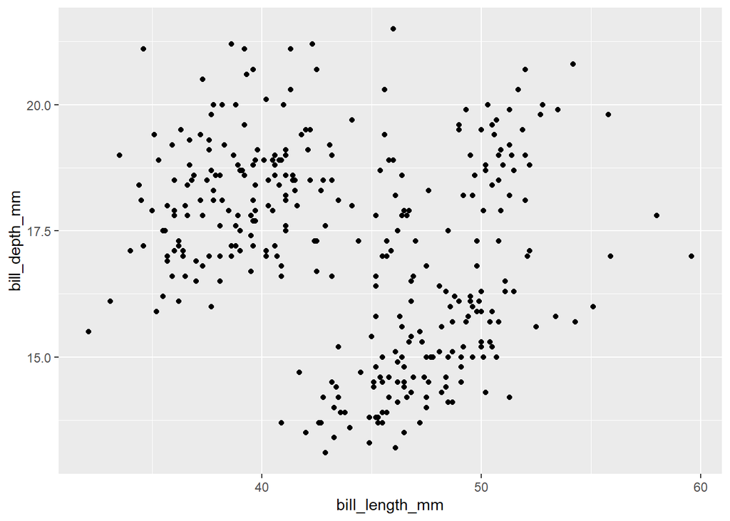

```r
penguins <- penguins %>% drop_na()

# Basic scatter plot
ggplot(penguins) +
  geom_point(aes(x = bill_length_mm,
                 y = bill_depth_mm))
```

For this workshop, we will mostly use a “simple” [RNA-seq dataset](https://www.ncbi.nlm.nih.gov/geo/query/acc.cgi?acc=GSE164073) on the transcriptional response to SARS-CoV-2 infection in eye tissue from human donors.

Run this cell first to do some quick data cleanup.

```r
counts <- read_csv("data/GSE164073_Eye_count_matrix.csv.gz")   # reads .gz directly
# Some genes have zero reads in every sample - let's drop them
counts <- counts %>% filter(rowSums(across(-Gene)) > 0)

expr <- counts %>%
  pivot_longer(-Gene, names_to = "sample", values_to = "count") %>%
  separate_wider_delim(sample, delim = "_",
                       names = c("id", "tissue", "condition", "replicate"),
                       cols_remove = FALSE) %>%
  mutate(condition = factor(condition, levels = c("mock", "CoV2"))) %>%
  group_by(sample) %>%
  mutate(cpm     = count / sum(count) * 1e6,   # counts per million
         log_cpm = log2(cpm + 1)) %>%
  ungroup()
```

Now let’s explore the dataset.

```r
head(expr, 5) # check the first 5 rows
```

| Gene | id | tissue | condition | replicate | sample | count | cpm | log_cpm |
| --- | --- | --- | --- | --- | --- | --- | --- | --- |
| A1BG | MW1 | cornea | mock | 1 | MW1_cornea_mock_1 | 91 | 4.199145 | 2.378274 |
| A1BG | MW2 | cornea | mock | 2 | MW2_cornea_mock_2 | 131 | 5.422301 | 2.683090 |
| A1BG | MW3 | cornea | mock | 3 | MW3_cornea_mock_3 | 86 | 3.865134 | 2.282480 |
| A1BG | MW4 | cornea | CoV2 | 1 | MW4_cornea_CoV2_1 | 77 | 3.643700 | 2.215275 |
| A1BG | MW5 | cornea | CoV2 | 2 | MW5_cornea_CoV2_2 | 69 | 2.985900 | 1.994906 |

We can also create a per-sample summary table. The whole dataset is one row per gene per sample, which is a lot (tens of thousands) of rows for each sample. Here, we take the 18 distinct samples and summarize their info into one row for each.

```r
samples <- expr %>%
  group_by(sample, tissue, condition, replicate) %>%
  summarise(library_size = sum(count), genes_detected = sum(count > 0), .groups = "drop")
```

We want to group by sample, but we also want to keep tissue, condition, and replicate in the output. So, we use `group_by(sample, tissue, condition, replicate)`. In `summarize`, we condense the info for each sample into `library_size` - how many reads across every gene in the sample?

We’ll use both `samples` and `expr` for our visualizations depending on what we want to compare going forward. Now, let’s use the dataset to build different useful plots!

### 1.1 bar plot

Bar plot is used to visually compare categorical data by representing values with rectangular bars.

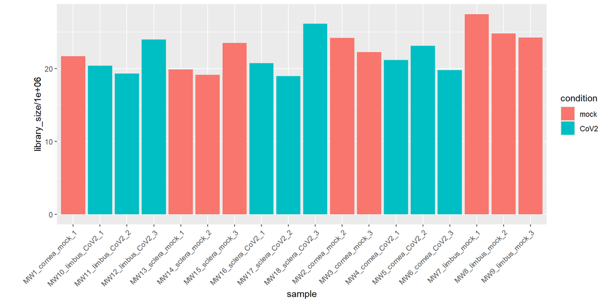

```r
# bar plot: discrete variable
ggplot(samples, aes(x = sample, y = library_size / 1e6, fill = condition)) +
  geom_col() +
  theme(axis.text.x = element_text(angle = 45, hjust = 1),
        plot.margin = margin(t = 5, r = 5, b = 5, l = 40))
```

### 1.2 histogram/ frequency/ density plot

A histogram, frequency plot, and density plot all visualize the distribution of a dataset, but they differ in how they represent data: a histogram groups data into bins and shows counts, a frequency plot connects points representing counts for each bin, and a density plot estimates the probability density function, providing a smooth representation of distribution shape.

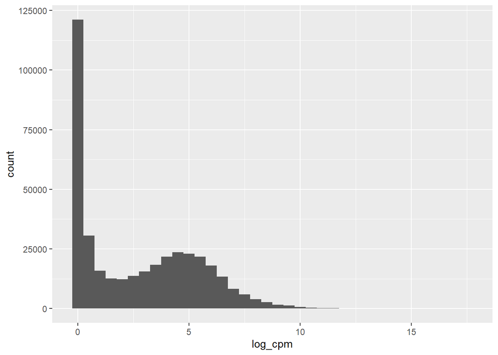

```r
# histogram plot: continuous variable
ggplot(expr, aes(x = log_cpm)) + geom_histogram(binwidth = 0.5)
```

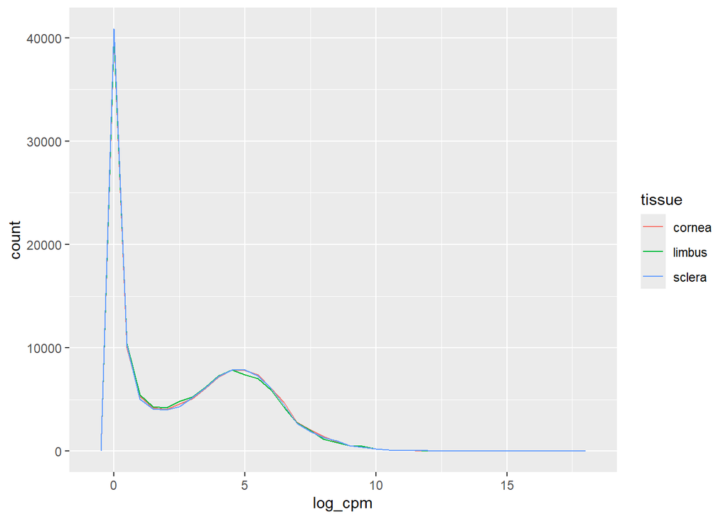

```r
# frequency plot
ggplot(expr, aes(x = log_cpm, colour = tissue)) + geom_freqpoly(binwidth = 0.5)
```

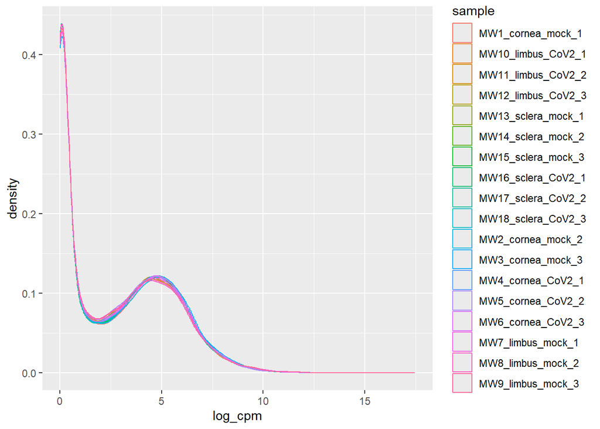

```r
# density plot (smooth histogram = density plot)
ggplot(expr, aes(x = log_cpm, colour = sample)) + geom_density()
```

### 1.3 box plot

A box plot is used to summarize the distribution of a dataset by displaying its median, quartiles, and potential outliers, helping to identify variability and skewness.

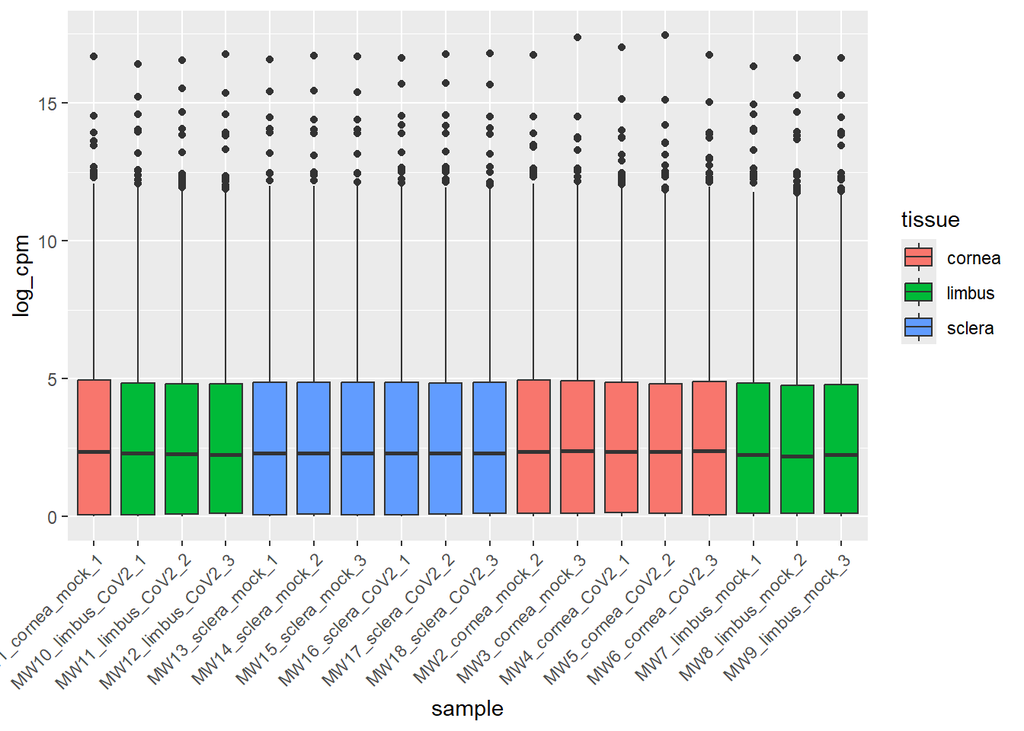

```r
# box plot: one discrete variable + one continuous variable
ggplot(expr, aes(x = sample, y = log_cpm, fill = tissue)) +
  geom_boxplot() +
  theme(axis.text.x = element_text(angle = 45, hjust = 1))
```

### 1.4 violin plot

A violin plot combines aspects of a box plot and a density plot to show the distribution, probability density, and variability of a dataset, making it easier to identify patterns and multimodal distributions.

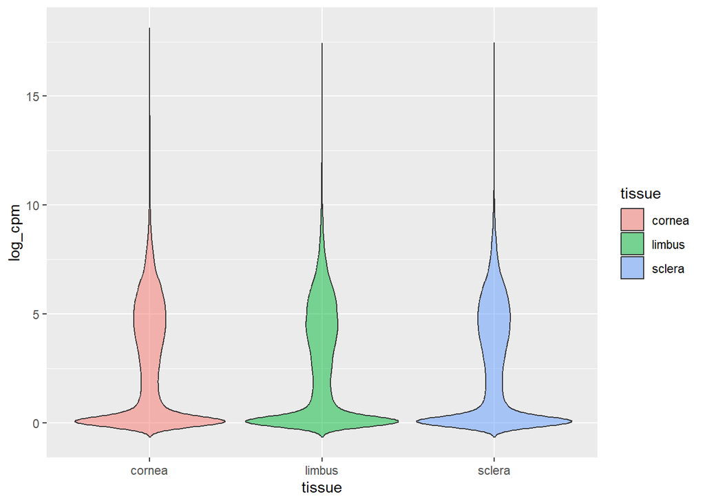

```r
# violin plot
ggplot(expr, aes(x = tissue, y = log_cpm, fill = tissue)) + geom_violin(trim = FALSE, alpha = 0.5)
```

```r
  stat_summary(
    fun = mean,
    fun.max = function(x) {
      mean(x) + sd(x)
    },
    fun.min = function(x) {
      mean(x) - sd(x)
    },
    geom = "pointrange"
  )
```

```
## geom_pointrange: na.rm = FALSE, orientation = NA
## stat_summary: fun.data = NULL, fun = function (x, ...)
## UseMethod("mean"), fun.max = function (x)
## {
##     mean(x) + sd(x)
## }, fun.min = function (x)
## {
##     mean(x) - sd(x)
## }, fun.args = list(), na.rm = FALSE, orientation = NA
## position_identity
```

### 1.5 Example 1

Let’s see an example of how to improve a data visualization plot step by step. We’ll look at our RNA-seq dataset to investigate how SARS-CoV-2 infection changes the expression of one gene, **SOD2**, in three tissues of the human eye.

SOD2 (superoxide dismutase 2) is an enzyme that protects cells from oxidative stress and is commonly switched on during inflammation. It is one of the genes that changes most clearly after infection in this dataset.

#### 1.5.1 Create the dataset we will use in this example

The count matrix has one row per gene and one column per sample. To compare samples fairly, we convert counts to counts per million (CPM) (correcting for each sample’s sequencing depth) and then log-transform them. We need every gene to calculate each sample’s library size, but we only keep SOD2 for this example.

```r
# total reads per sample (library size), named by sample
lib_size <- colSums(counts[, -1])

sod2_df <- counts %>%
  filter(Gene == "SOD2") %>%
  pivot_longer(-Gene, names_to = "sample", values_to = "count") %>%
  # sample names look like "MW4_cornea_CoV2_1"
  separate_wider_delim(
    sample,
    delim = "_",
    names = c("id", "tissue", "condition", "replicate"),
    cols_remove = FALSE
  ) %>%
  mutate(
    log_cpm = log2(count / lib_size[sample] * 1e6 + 1),
    tissue = str_to_title(tissue),
    condition = fct_recode(
      factor(condition, levels = c("mock", "CoV2")),
      Mock = "mock",
      `SARS-CoV-2` = "CoV2"
    ),
    # one x-axis group per tissue x condition, in a sensible order
    group = factor(
      paste(tissue, condition, sep = "\n"),
      levels = paste(rep(c("Cornea", "Limbus", "Sclera"), each = 2),
                     c("Mock", "SARS-CoV-2"), sep = "\n")
    )
  ) %>%
  select(sample, tissue, condition, group, log_cpm)

head(sod2_df)
```

| sample | tissue | condition | group | log_cpm |
| --- | --- | --- | --- | --- |
| MW1_cornea_mock_1 | Cornea | Mock | Cornea\nMock | 7.317886 |
| MW2_cornea_mock_2 | Cornea | Mock | Cornea\nMock | 7.574831 |
| MW3_cornea_mock_3 | Cornea | Mock | Cornea\nMock | 7.334926 |
| MW4_cornea_CoV2_1 | Cornea | SARS-CoV-2 | Cornea\nSARS-CoV-2 | 10.397855 |
| MW5_cornea_CoV2_2 | Cornea | SARS-CoV-2 | Cornea\nSARS-CoV-2 | 10.342562 |
| MW6_cornea_CoV2_3 | Cornea | SARS-CoV-2 | Cornea\nSARS-CoV-2 | 10.431789 |

Let’s also define a theme once here so that we don’t have to keep repeating it for following code blocks:

```r
theme_example <- theme_classic(base_size = 14) +
  theme(
    axis.text = element_text(color = "black", size = 12),
    plot.margin = margin(3, 7, 3, 1.5)
  )

y_label <- "SOD2 expression (log2 CPM + 1)"
```

#### 1.5.2 What’s the problem of the following plot?

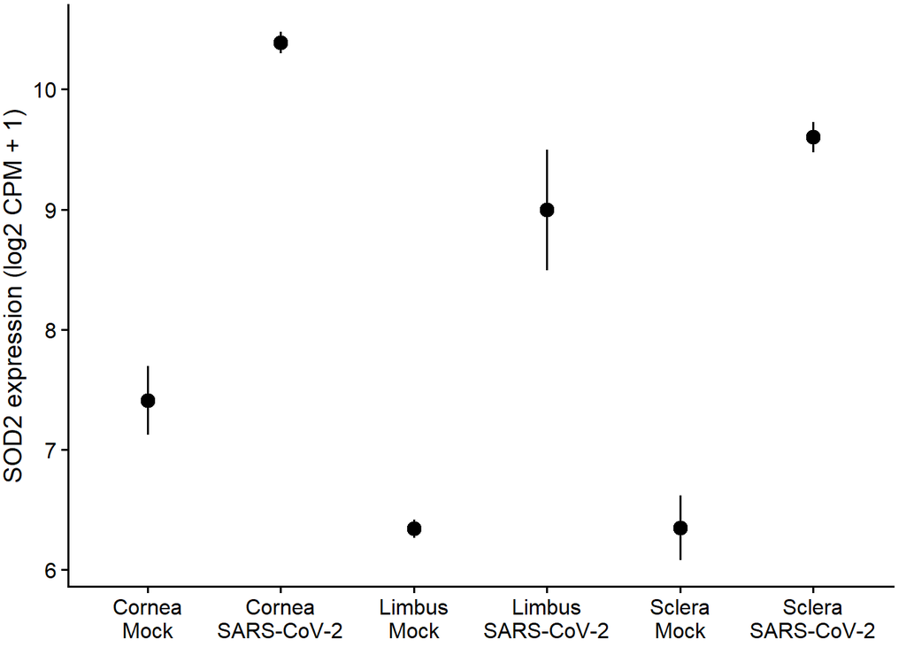

```r
# points-errorbars
sod2_errbar <- sod2_df %>%
  ggplot(aes(x = group, y = log_cpm)) +
  stat_summary(
    fun = mean,
    fun.max = function(x) {
      mean(x) + 2 * sd(x)
    },
    fun.min = function(x) {
      mean(x) - 2 * sd(x)
    },
    geom = "pointrange"
  ) +
  xlab(NULL) +
  ylab(y_label) +
  theme_example

sod2_errbar
```

#### 1.5.3 Use box/violin plot to show the distribution

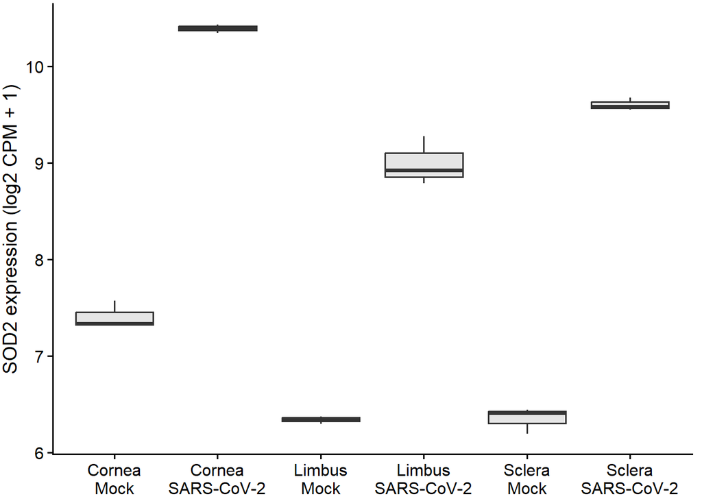

```r
# box plot
sod2_box <- sod2_df %>%
  ggplot(aes(x = group, y = log_cpm)) +
  geom_boxplot(fill = "grey90") +
  xlab(NULL) +
  ylab(y_label) +
  theme_example

sod2_box
```

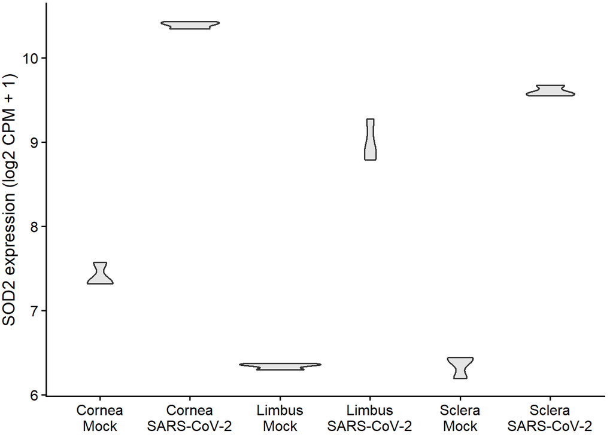

```r
# violin plot
sod2_violin <- sod2_df %>%
  ggplot(aes(x = group, y = log_cpm)) +
  geom_violin(fill = "grey90") +
  xlab(NULL) +
  ylab(y_label) +
  theme_example

sod2_violin
```

#### 1.5.4 Use points to show the original data

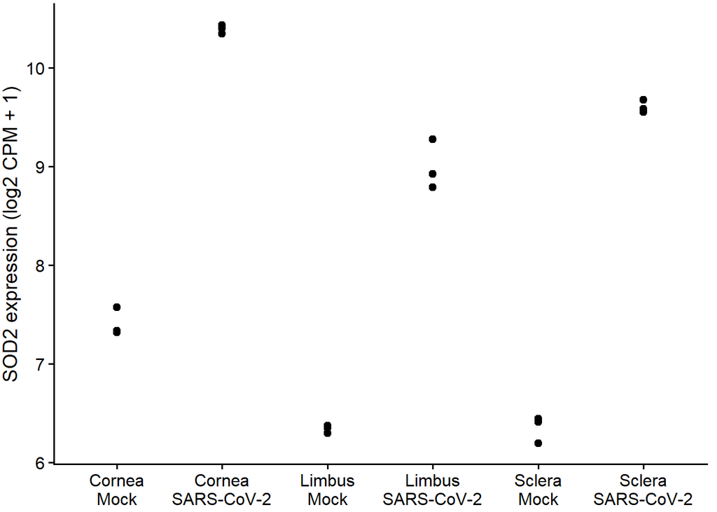

```r
# points
sod2_points <- sod2_df %>%
  ggplot(aes(x = group, y = log_cpm)) +
  geom_point(size = 2) +
  xlab(NULL) +
  ylab(y_label) +
  theme_example

sod2_points
```

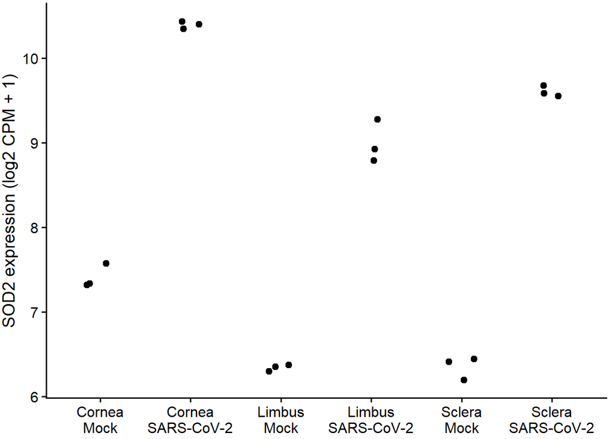

```r
# jitter points
sod2_jitter <- sod2_df %>%
  ggplot(aes(x = group, y = log_cpm)) +
  geom_point(
    position = position_jitter(width = .15, height = 0, seed = 320),
    size = 2
  ) +
  xlab(NULL) +
  ylab(y_label) +
  theme_example

sod2_jitter
```

#### 1.5.5 Use sina plot to combine violin plot and jitter points?

What if we combine two things, and add in the data points to a violin plot to see if the points show the distribution’s shape?

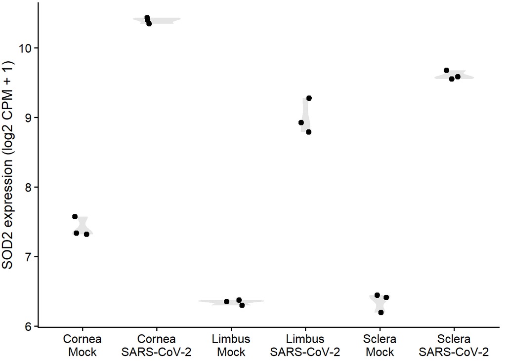

```r
# violin + jitter
sod2_violin_jitter <- sod2_df %>%
  ggplot(aes(x = group, y = log_cpm)) +
  geom_violin(color = "transparent", fill = "gray90") +
  geom_jitter(width = 0.15, height = 0, size = 2) +
  xlab(NULL) +
  ylab(y_label) +
  theme_example

sod2_violin_jitter
```

With only 3 points per group, the violin plot is shapes that aren’t necessarily reflecting the data. With small sample sizes, using a technique that shows the raw points is the best. Let’s try something else.

#### 1.5.6 A better plot for small groups: points with a mean

Instead of a violin, we can add a short line at each group’s mean and use color to separate the conditions.

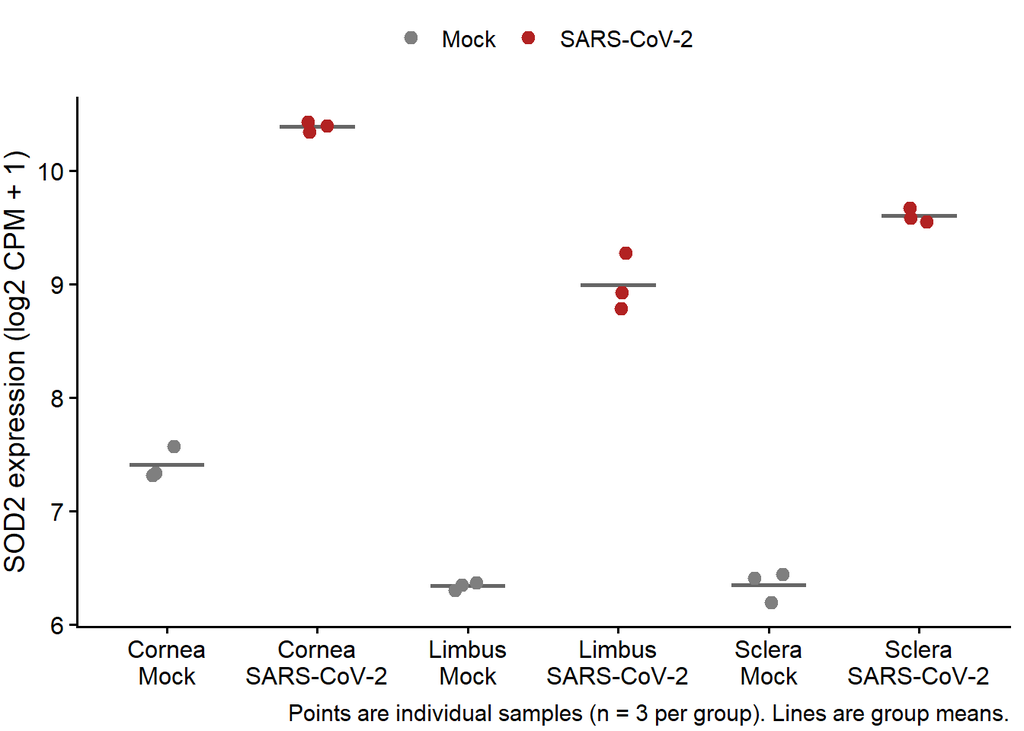

```r
sod2_final <- sod2_df %>%
  ggplot(aes(x = group, y = log_cpm, color = condition)) +
  stat_summary(
    fun = mean,
    geom = "crossbar",
    width = 0.5,
    linewidth = 0.4,
    color = "grey40"
  ) +
  geom_point(
    position = position_jitter(width = .1, height = 0, seed = 320),
    size = 2.5
  ) +
  scale_color_manual(values = c(Mock = "grey50", `SARS-CoV-2` = "firebrick")) +
  xlab(NULL) +
  ylab(y_label) +
  labs(
    color = NULL,
    caption = "Points are individual samples (n = 3 per group). Lines are group means."
  ) +
  theme_example +
  theme(legend.position = "top")

sod2_final
```

Compared with the earlier plot, the reader can now see every measurement, how many samples there are, and how consistent the replicates are.

## Module 2: Advanced Customization and Data Transformation

### 2.0 Prepare the dataset

Let’s continue using the same RNA-seq dataset, but we’ll create one more small table to use in our plotting. This one is genes by sample and each gene’s variance across samples.

```r
library(tidyverse)
library(colorspace)
```

```r
# long format: one row per gene per sample
expr <- counts %>%
  pivot_longer(-Gene, names_to = "sample", values_to = "count") %>%
  separate_wider_delim(
    sample,
    delim = "_",
    names = c("id", "tissue", "condition", "replicate"),
    cols_remove = FALSE
  ) %>%
  mutate(condition = factor(condition, levels = c("mock", "CoV2"))) %>%
  group_by(sample) %>%
  mutate(
    cpm = count / sum(count) * 1e6,   # counts per million
    log_cpm = log2(cpm + 1)
  ) %>%
  ungroup() %>%
  mutate(group = factor(
    paste(tissue, condition),
    levels = c("cornea mock", "cornea CoV2",
               "limbus mock", "limbus CoV2",
               "sclera mock", "sclera CoV2")
  ))

# one row per sample
samples <- expr %>%
  group_by(sample, tissue, condition, replicate) %>%
  summarise(
    library_size = sum(count) / 1e6,   # millions of reads
    genes_detected = sum(count > 0),
    .groups = "drop"
  )

# gene x sample matrix of log_cpm, and each gene's variance across samples
expr_mat <- expr %>%
  select(Gene, sample, log_cpm) %>%
  pivot_wider(names_from = sample, values_from = log_cpm) %>%
  column_to_rownames("Gene") %>%
  as.matrix()

gene_var <- apply(expr_mat, 1, var)
```

### 2.1 Data Transformations and Faceting

In data visualization, data transformation is a crucial step to ensure that the data is in the right format and structure for effective visual representation.

#### 2.1.1 Log Transformation

There are many different data transformation methods, and the following is an example of log transformation.

We would like to investigate the relationship between how highly a gene is expressed and how much it changes after SARS-CoV-2 infection, across different tissues. (This is also called an MA plot.)

```r
# Step 1: calculate the mean CPM of each gene in mock and infected samples, per tissue
gene_summary <- expr %>%
  group_by(tissue, Gene, condition) %>%
  summarise(mean_cpm = mean(cpm), .groups = "drop") %>%
  pivot_wider(names_from = condition, values_from = mean_cpm) %>%
  mutate(
    avg_cpm = (mock + CoV2) / 2,               # average expression
    log2FC = log2((CoV2 + 1) / (mock + 1))     # log2 fold change, infected vs mock
  ) %>%
  filter(avg_cpm >= 1)                         # drop barely expressed genes
gene_summary
```

| tissue | Gene | mock | CoV2 | avg_cpm | log2FC |
| --- | --- | --- | --- | --- | --- |
| cornea | A1BG | 4.495527e+00 | 3.425213e+00 | 3.960370 | -3.125107e-01 |
| cornea | A1BG-AS1 | 1.246969e+01 | 1.133367e+01 | 11.901678 | -1.271144e-01 |
| cornea | A2M | 1.162895e+01 | 7.926262e+00 | 9.777609 | -5.006071e-01 |
| cornea | A4GALT | 1.955581e+01 | 2.541080e+01 | 22.483304 | 3.615820e-01 |
| cornea | AAAS | 3.881177e+01 | 3.371097e+01 | 36.261369 | -1.978032e-01 |
| cornea | AACS | 3.625943e+01 | 3.875461e+01 | 37.507023 | 9.351648e-02 |
| cornea | AADAT | 4.336222e+00 | 4.363042e+00 | 4.349632 | 7.232920e-03 |
| cornea | AAGAB | 4.976579e+01 | 4.352648e+01 | 46.646134 | -1.891929e-01 |
| cornea | AAK1 | 6.270128e+01 | 6.581179e+01 | 64.256534 | 6.878043e-02 |
| cornea | AAMDC | 7.827001e+00 | 7.140102e+00 | 7.483551 | -1.168766e-01 |

[output cut: 9990 more lines]

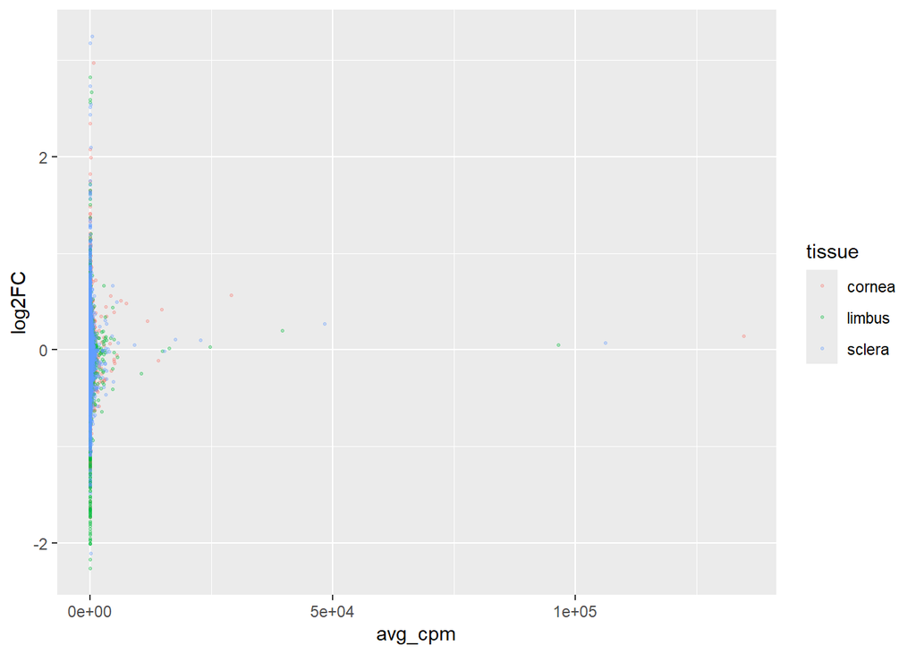

```r
# Step 2: draw the plot
gene_summary %>%
  ggplot(aes(x = avg_cpm, y = log2FC)) +
    geom_point(aes(color = tissue), size = 0.5, alpha = 0.3)
```

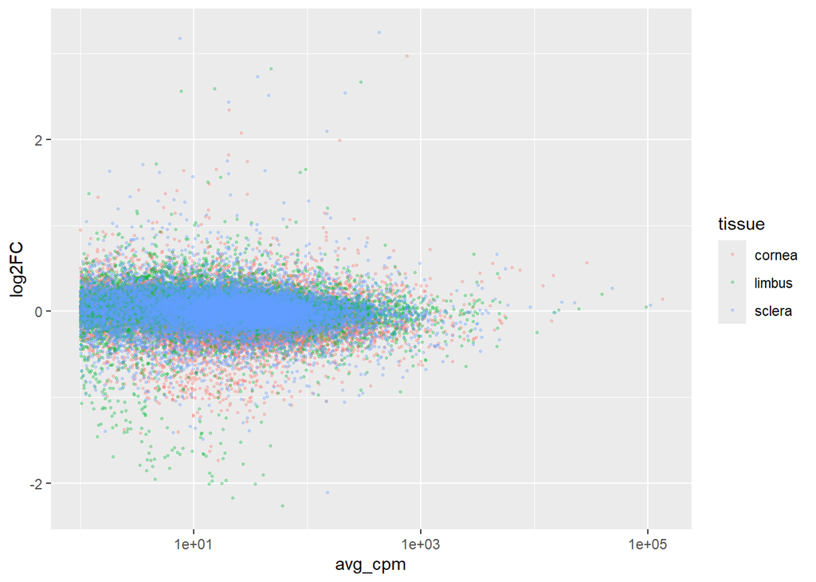

```r
# Step 3: log transformation of x-axis (avg_cpm)
gene_summary %>%
  ggplot(aes(x = avg_cpm, y = log2FC)) +
    geom_point(aes(color = tissue), size = 0.5, alpha = 0.3) +
    scale_x_log10()
```

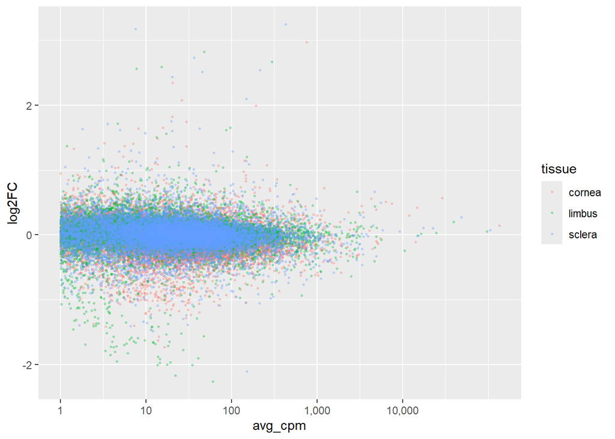

```r
# Step 4 (Optional): add comma format or unit format to label the axis for better interpretation
gene_summary %>%
  ggplot(aes(x = avg_cpm, y = log2FC)) +
    geom_point(aes(color = tissue), size = 0.5, alpha = 0.3) +
    scale_x_log10(breaks = c(1, 10, 100, 1000, 10000),
                  labels = scales::label_comma())
```

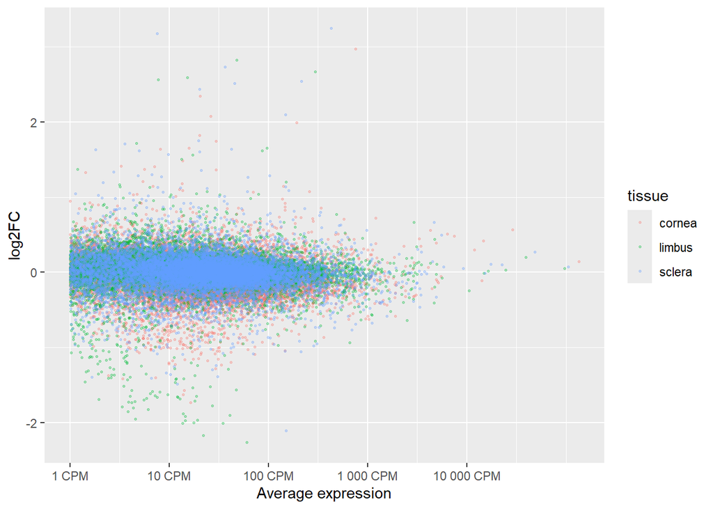

```r
gene_summary %>%
  ggplot(aes(x = avg_cpm, y = log2FC)) +
    geom_point(aes(color = tissue), size = 0.5, alpha = 0.3) +
    scale_x_log10(
      name = "Average expression",
      breaks = c(1, 10, 100, 1000, 10000),
      labels = scales::unit_format(unit = "CPM"))
```

#### 2.1.2 Faceting

Data faceting is used in data visualization to break down data into subsets and display them across multiple smaller plots. This technique helps in revealing patterns, trends, and relationships that might be obscured in a single, aggregated plot. The following is an example of data faceting.

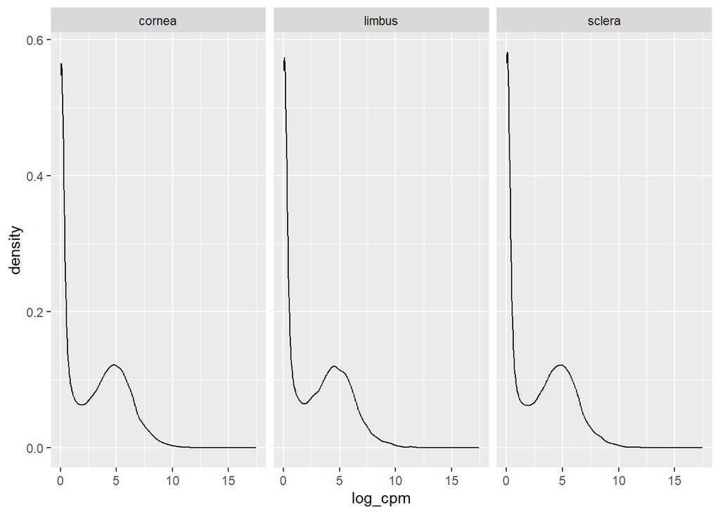

```r
# facet_grid(): create a grid of graphs, by rows and columns
expr %>%
  ggplot(aes(x = log_cpm)) +
  geom_density() +
  facet_grid(. ~ tissue)
```

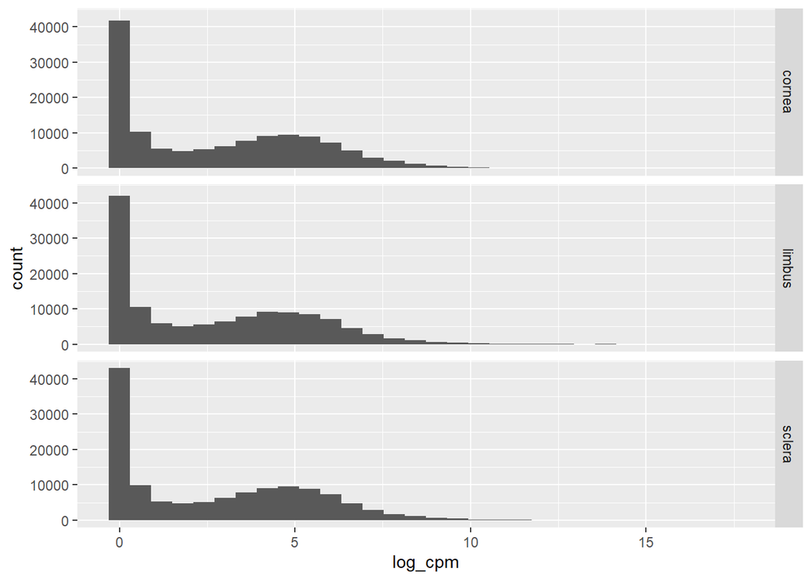

```r
expr %>%
  ggplot(aes(x = log_cpm)) +
  geom_histogram() +
  facet_grid(tissue ~ .)
```

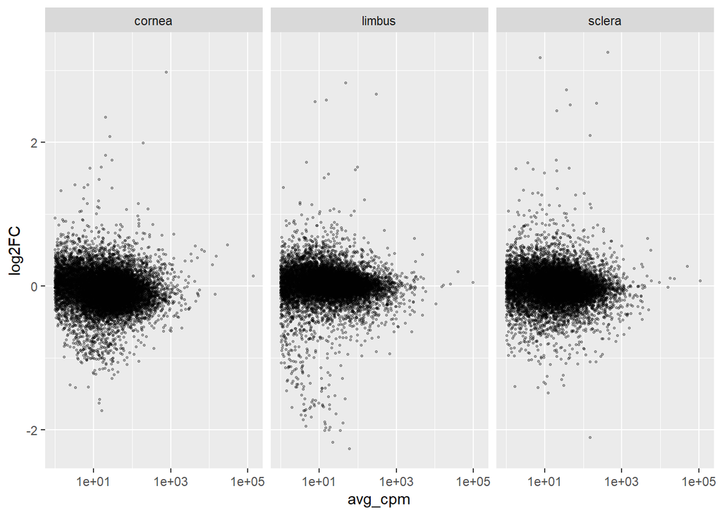

```r
# facet_wrap(): create small multiples by "wrapping" a series of plots
gene_summary %>%
  ggplot(aes(x = avg_cpm, y = log2FC)) +
  geom_point(size = 0.5, alpha = 0.3, show.legend = FALSE) +
  scale_x_log10() +
  facet_wrap(~tissue)
```

### 2.2 Advanced Aesthetic Customization - color

Color plays a crucial role in data visualization. We will explore how to use ColorSpace to create plots tailored to different data types.

Show all available color in colorspace.

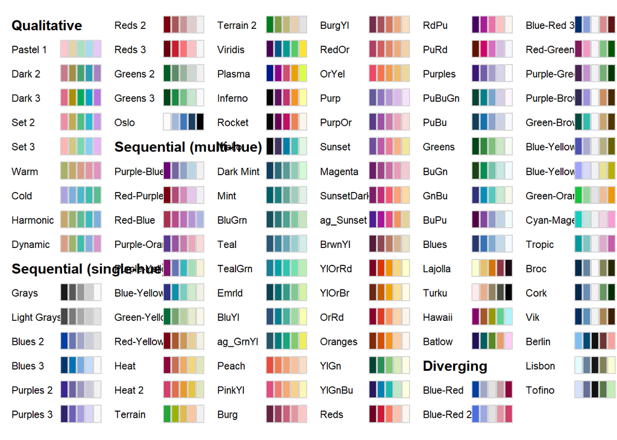

```r
hcl_palettes(plot = TRUE)
```

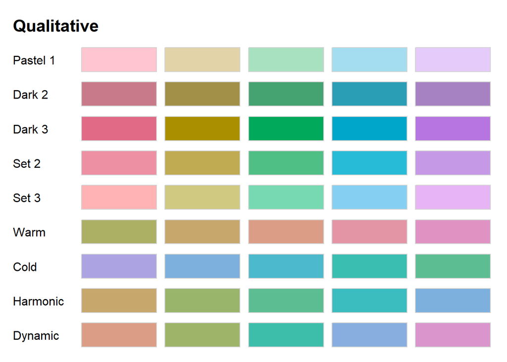

```r
hcl_palettes("qualitative", plot = TRUE)
```

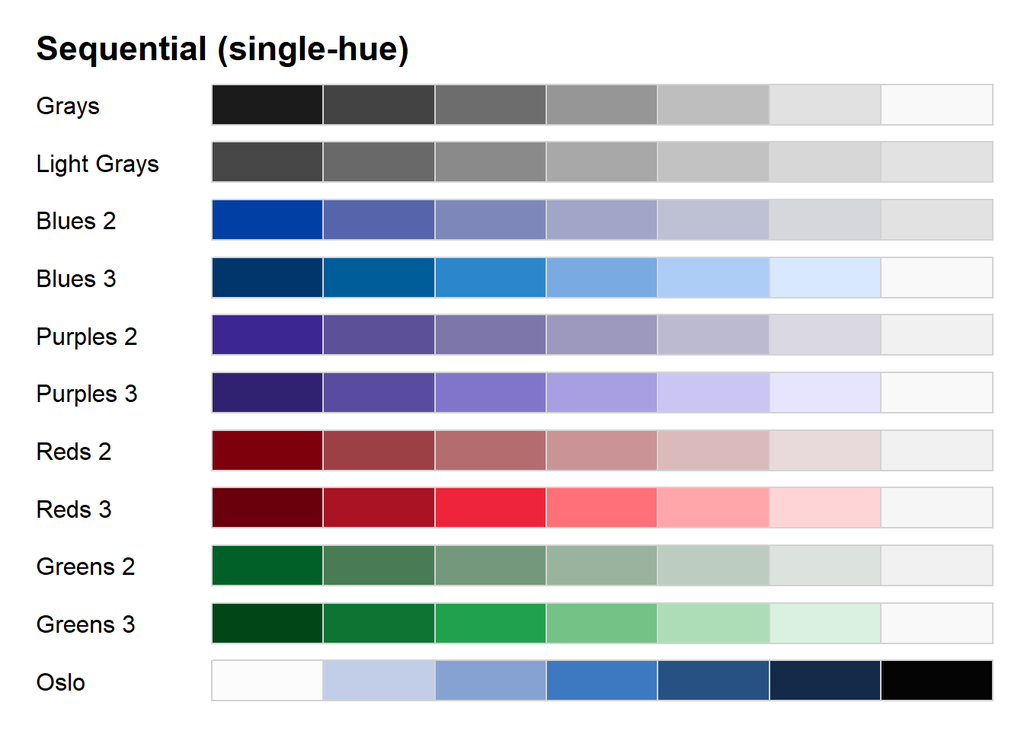

```r
hcl_palettes("sequential (single-hue)", n = 7, plot = TRUE)
```

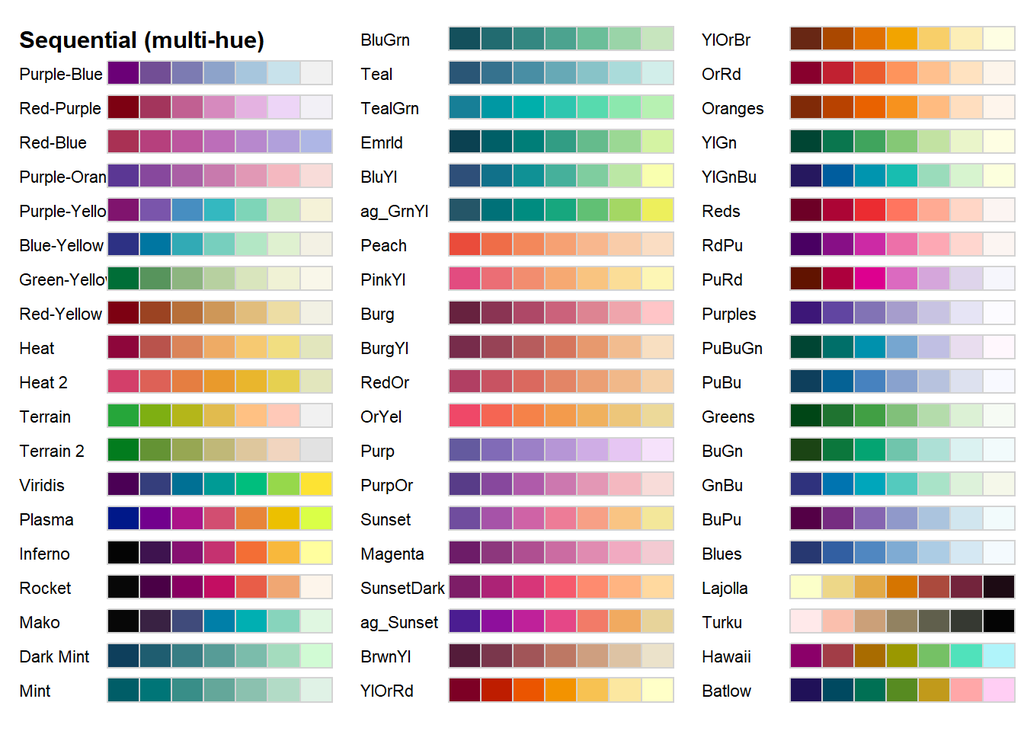

```r
hcl_palettes("sequential (multi-hue)", n = 7, plot = TRUE)
```

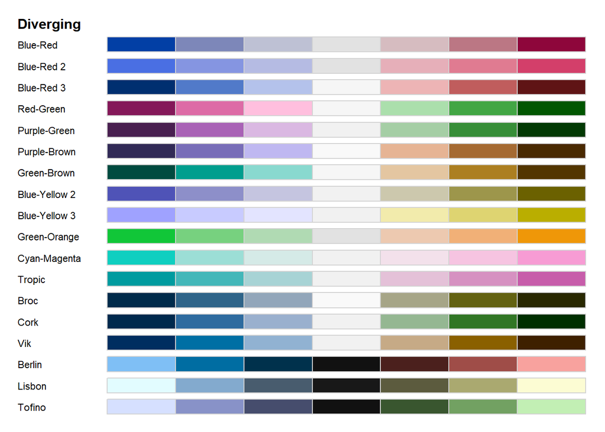

```r
hcl_palettes("diverging", n = 7, plot = TRUE)
```

#### 2.2.1 qualitative colors

Qualitative (PCA of samples): principal component analysis (PCA) summarizes the expression of many genes into a few new variables (PC1, PC2, …) that capture the biggest differences between samples. Create a scatter plot of PC1 vs. PC2, coloring points by tissue.

Qualitative (iris dataset) : create a scatter plot of Sepal.Length vs. Sepal.Width, coloring points by Species.

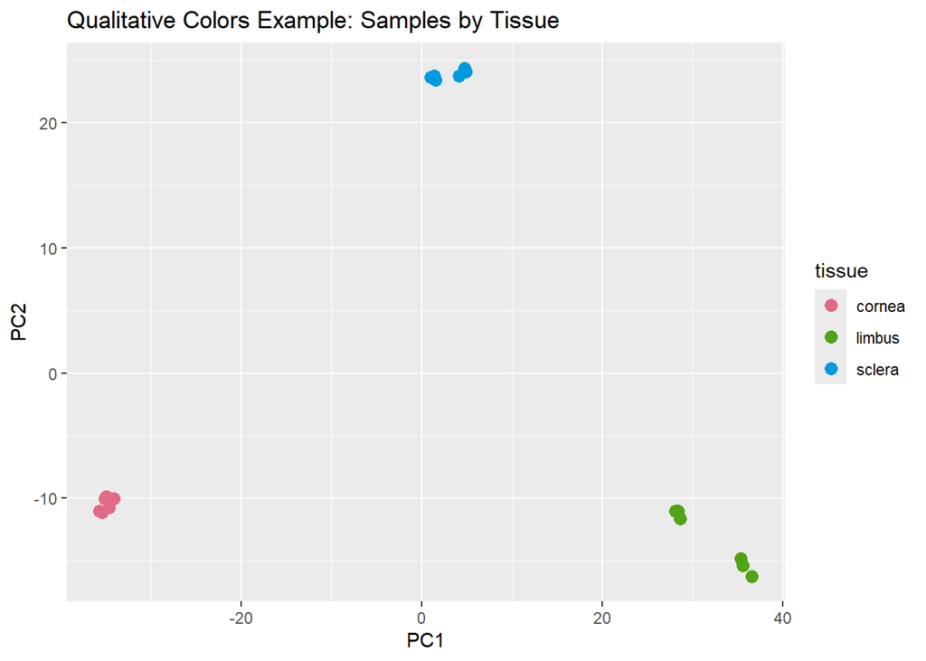

```r
# Example - RNA-seq data
# PCA on the 500 most variable genes
top500 <- names(sort(gene_var, decreasing = TRUE))[1:500]
pca <- prcomp(t(expr_mat[top500, ]))

pca_df <- as_tibble(pca$x[, 1:2], rownames = "sample") %>%
  left_join(samples, by = "sample")

# qualitative colors (Categorical Data)
ggplot(pca_df, aes(x = PC1, y = PC2, color = tissue)) +
  geom_point(size = 3) +
  scale_color_discrete_qualitative(palette = "Dark 3") +  # Using discrete qualitative color scale
  ggtitle("Qualitative Colors Example: Samples by Tissue")
```

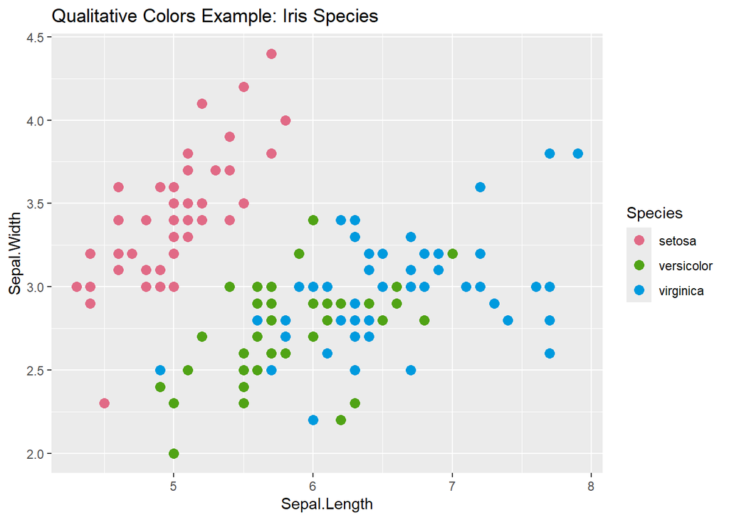

```r
# Example: built-in iris data set
ggplot(iris, aes(x = Sepal.Length, y = Sepal.Width, color = Species)) +
  geom_point(size = 3) +
  scale_color_discrete_qualitative(palette = "Dark 3") +  # Using discrete qualitative color scale
  ggtitle("Qualitative Colors Example: Iris Species")
```

#### 2.2.2 Sequential(single-hue) colors

Sequential single-hue (samples table): create a bar plot of samples based on their library size (total reads, in millions), using a single-hue sequential color gradient.

Sequential single-hue (mtcars dataset): create a bar plot of car models (rownames(mtcars)) based on their miles per gallon (mpg), using a single-hue sequential color gradient.

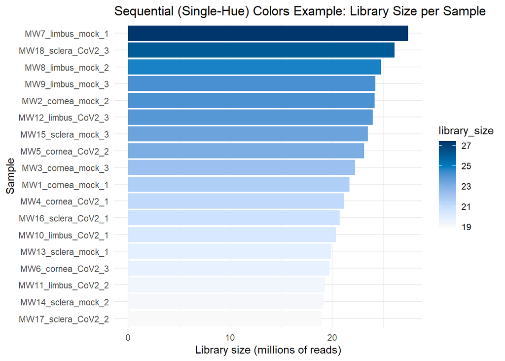

```r
# sequential (single-hue) colors (Ordered Data - RNA-seq example)
ggplot(samples, aes(x = reorder(sample, library_size), y = library_size, fill = library_size)) +
  geom_bar(stat = "identity") +
  scale_fill_continuous_sequential(palette = "Blues 3") +  # Sequential color for fill
  coord_flip() + # Flip for better readability
  ylab("Library size (millions of reads)") +
  xlab("Sample") +
  ggtitle("Sequential (Single-Hue) Colors Example: Library Size per Sample") +
  theme_minimal()
```

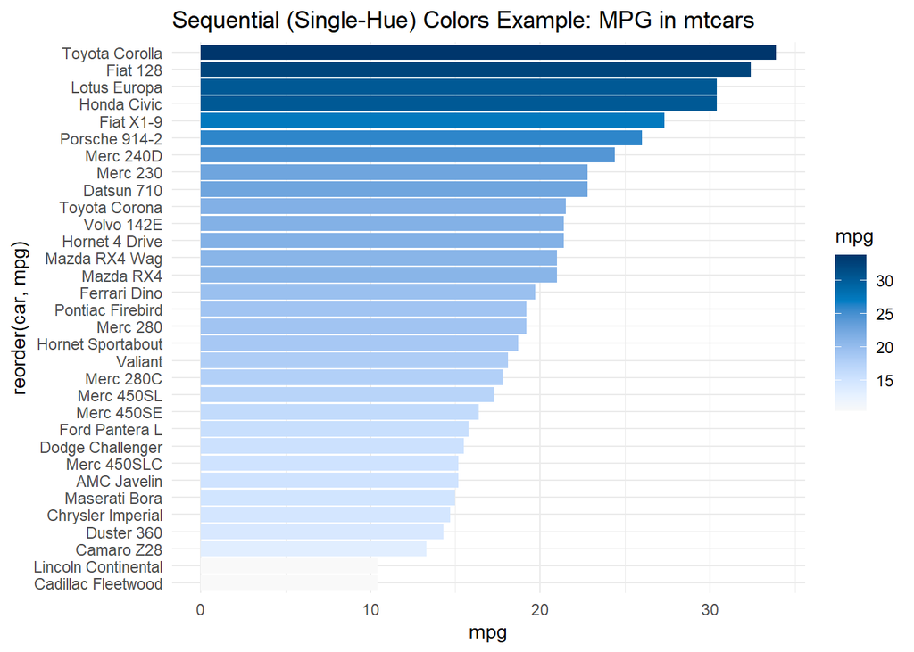

```r
# sequential (single-hue) colors (Ordered Data)
# Order data by mpg
mtcars$car <- rownames(mtcars)
mtcars <- mtcars[order(mtcars$mpg), ]
# Create a bar plot
ggplot(mtcars, aes(x = reorder(car, mpg), y = mpg, fill = mpg)) +
  geom_bar(stat = "identity") +
  scale_fill_continuous_sequential(palette = "Blues 3") +  # Sequential color for fill
  coord_flip() + # Flip for better readability
  ggtitle("Sequential (Single-Hue) Colors Example: MPG in mtcars") +
  theme_minimal()
```

#### 2.2.3 Sequential (multi-hue) colors

Sequential multi-hue (expression heatmap): the heatmap shows the expression of the 30 most variable genes in every sample using color intensity. It highlights which genes are highly expressed in which samples.

Sequential multi-hue (volcano dataset): The volcano heatmap provides a 2D topographic view of elevation data using color intensity. It highlights how terrain elevation changes over space.

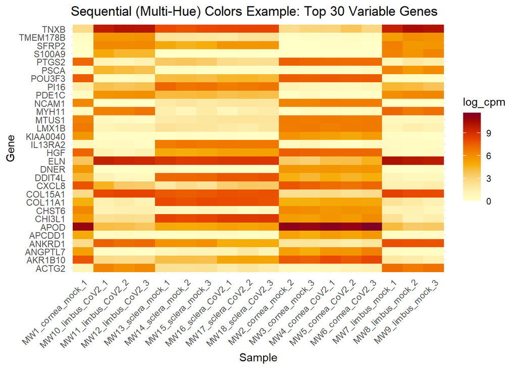

```r
# Example: RNA-seq dataset
# sequential (multi-hue) colors (Ordered Data)
top30 <- names(sort(gene_var, decreasing = TRUE))[1:30]

# Plot the heatmap
expr %>%
  filter(Gene %in% top30) %>%
  ggplot(aes(x = sample, y = Gene, fill = log_cpm)) +
  geom_tile() +
  scale_fill_continuous_sequential(palette = "YlOrRd") +  # Sequential multi-hue color scale
  ggtitle("Sequential (Multi-Hue) Colors Example: Top 30 Variable Genes") +
  xlab("Sample") +
  ylab("Gene") +
  theme_minimal() +
  theme(axis.text.x = element_text(angle = 45, hjust = 1))
```

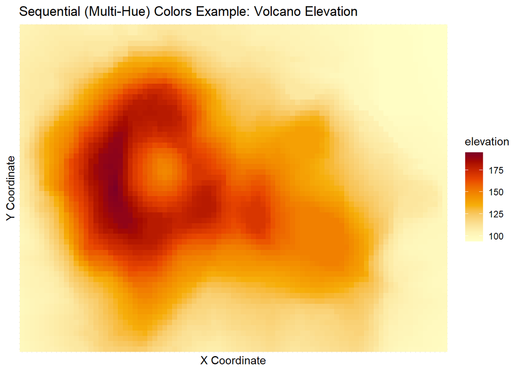

```r
# sequential (multi-hue) colors (Ordered Data)
# Convert volcano dataset to long format for ggplot
volcano_df <- as.data.frame(as.table(volcano))
colnames(volcano_df) <- c("x", "y", "elevation")
# Plot the heatmap
ggplot(volcano_df, aes(x = x, y = y, fill = elevation)) +
  geom_tile() +
  scale_fill_continuous_sequential(palette = "YlOrRd") +  # Sequential multi-hue color scale
  ggtitle("Sequential (Multi-Hue) Colors Example: Volcano Elevation") +
  xlab("X Coordinate") +  # Add x-axis label
  ylab("Y Coordinate") +  # Add y-axis label
  theme_minimal() +
  theme(
    axis.text = element_blank(),   # Remove axis text
    axis.ticks = element_blank()   # Remove axis ticks
  )
```